# Exercise5

Perttu Kajatkari

11/26/2020

# Exercise 5 - Dimensionality reduction

In this exercise we used data that was wrangled together from human development and gender inequality data by country. We have variables:

- “country”
- “edu2F” (Proportion of females with at least secondary education)
- “labourF” (Proportion of females in the labour force)
- “exp.edu” (Expected years of schooling, both sexes)
- “life.exp” (average life expectancy)
- “GNI” (Gross National Income per capita)
- “mat.mort”(Maternal mortality ratio)
- “ado.birth” (Adolescent birth rate)
- “parl.rep” (Percetange of female representatives in parliament)

## Reading in and checking the data

```r
#load libraries
library(dplyr); library(GGally)

human <- read.table("./data/human.txt",header=TRUE)
# First, check that the structure of the data is OK
dim(human)
```

```
## [1] 155   8
```

```r
str(human)
```

```
## 'data.frame':    155 obs. of  8 variables:
##  $ edu2F    : num  97.4 94.3 95 95.5 87.7 96.3 80.5 95.1 100 95 ...
##  $ labourF  : num  61.2 58.8 61.8 58.7 58.5 53.6 53.1 56.3 61.6 62 ...
##  $ exp.edu  : num  17.5 20.2 15.8 18.7 17.9 16.5 18.6 16.5 15.9 19.2 ...
##  $ life.exp : num  81.6 82.4 83 80.2 81.6 80.9 80.9 79.1 82 81.8 ...
##  $ GNI      : int  64992 42261 56431 44025 45435 43919 39568 52947 42155 32689 ...
##  $ mat.mort : int  4 6 6 5 6 7 9 28 11 8 ...
##  $ ado.birth: num  7.8 12.1 1.9 5.1 6.2 3.8 8.2 31 14.5 25.3 ...
##  $ parl.rep : num  39.6 30.5 28.5 38 36.9 36.9 19.9 19.4 28.2 31.4 ...
```

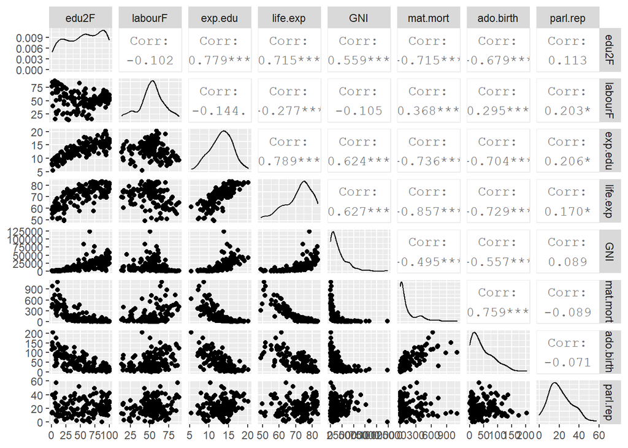

```r
ggpairs(human)
```

Many of the distributions seem to be normal, or at least they are a blend of normal distribution and something else. Some of the more skewed distributions appear also to be normal, but they are only capped at the left hand side (GNI, maternal mortality, for instance). There are quite a few strong correlations (education increases life expectancy). GNI has a tendency to correlate with just about everything, but there is a weird phenomenon, that for some variables, the correlation appears to be more like a condition than an explanation (for the lack of a better word). For example, maternal mortality can be high only if GNI is low, but a low GNI does not predict explicitly, what the maternal mortality will be.